# Advanced Analytics and Machine Learning Project Report

Jim Leach

This report has interactive elements and is best viewed using a modern web browser such as Mozilla Firefox or Google Chrome. Printing is possible but will not produce an optimal reading experience. The `R` code used to perform these analyses has been provided as supplementary files, and can be viewed in this report using the *Code* buttons to toggle code viewing. It is also available on the [online repository](https://github.com/Jim89/icl/tree/master/ml/project). Please note that submission of a report of this nature and format was discussed with Dr. Wei Pan who stated that it was entirely acceptable.

```r
# Load packages used in the analysis
library(readr)
library(dplyr)
library(tidyr)
library(quanteda)
library(igraph)
library(networkD3)
library(stringr)
library(ggplot2)

# Set up ggplot2 theme object for prettier plots later
theme_jim <-  theme(legend.position = "bottom",
                    axis.text.y = element_text(size = 16, colour = "black"),
                    axis.text.x = element_text(size = 16, colour = "black"),
                    legend.text = element_text(size = 16),
                    legend.title = element_text(size = 16),
                    title = element_text(size = 16),
                    strip.text = element_text(size = 16, colour = "black"),
                    strip.background = element_rect(fill = "white"),
                    panel.grid.minor.x = element_blank(),
                    panel.grid.major.x = element_line(colour = "grey", linetype = "dotted"),
                    panel.grid.minor.y = element_line(colour = "lightgrey", linetype = "dotted"),
                    panel.grid.major.y = element_line(colour = "grey", linetype = "dotted"),
                    panel.margin.y = unit(0.1, units = "in"),
                    panel.background = element_rect(fill = "white", colour = "lightgrey"),
                    panel.border = element_rect(colour = "black", fill = NA))

# Get the data with readr
emails <- read_csv("./data/Emails.csv")
aliases <- read_csv("./data/Aliases.csv")
receivers <- read_csv("./data/EmailReceivers.csv")
people <- read_csv("./data/Persons.csv")

# Set rownames for easier use later
rownames(emails) <- emails$DocNumber

# Define z-score helper function
# z_score is a function that takes in a numeric vector and z-score's it,
# subtracting the mean from each element, before dividing by the standard deviation
z_score <- function(vec) {
    ans <- (vec - mean(vec)) / sd(vec)
    return(ans)
}
```

# 1 Abstract

*This report presents an analysis of emails released by Hillary Clinton following the discovery that she had used a private email server for email correspondence whilst acting as the United States’ Secretary of State. The network structure of Mrs. Clinton’s email contacts is investigated, and attempts made to identify important players in this network.*

Previous work on the detection of dishonesty in text is applied to attempt to explore levels of potentially dishonest emails. The relationship between an email sender’s importance, and the likelihood that the email is potentially dishonest in nature is examined.

Success is found investigating the network structure of the email contacts, particularly in identifying important individuals. No significant relationships between importance and potential dishonesty are found.

# 2 Introduction

In 2015 Hillary Clinton, a former US First Lady and later Secretary of State, was revealed to have used a private email server for much of her official correspondence. This revelation caused controversy, leading to the release of an [official statement](https://www.hillaryclinton.com/hillarys-emails-four-sentences/). All emails were provided to the US State Department and in August 2015, after several Freedom of Information Requests, 7000 pages were released to the public (many in a highly redacted form). The release contained not only email content, but also associated metadata including sender, receiver and individuals in carbon copy (“CC”). This paper explores those emails and performs analysis of metadata *and* content to understand. The questions approached can be summarised as:

> - Can the network structure of Mrs. Clinton’s email contacts be used to identify people of importance?
> - Can groups of individuals be identified within the network?
> - Applying previous work on detection of dishonesty in text, is there a difference in levels of potential dishonesty amongst detected groups?
> - Is there a relationship between an individual’s importance, and their predicted probability of dishonesty?

The detection of both people of importance and communities in social networks can be a difficult prospect (*Network Analytics*, MSc. Business Analytics, 2015/16, *Kalyan Talluri*). This paper seeks to understand if the email data provided can be used to perform both tasks for Mrs. Clinton email contacts. Using metadata of sender, receiver and CC individuals, a simple network was constructed from these data. Common analytical techniques ([centrality measures](http://faculty.ucr.edu/~hanneman/nettext/C10_Centrality.html) (Hanneman and Riddle, 2005)) were used to identify individuals of importance. The results were promising when comparing to the known identities of individuals. Community detection was also employed using two algorithms: [walktrap](http://arxiv.org/abs/physics/0512106) (Pons and Latapy, 2005), and [edge betweenness](http://arxiv.org/abs/cond-mat/0308217) (Newman and Girvan, 2003). The walktrap algorithm produced reasonable results, detecting two main communities in the data.

Earlier work has shown that document *content* can be used to detect dishonesty within it (Newman et. al, 2003). This work produced models to predict levels of (dis)honesty in a document based on the proportion of certain categories of words within it. Using tools from the [Linguistic Inquiry Word Count](http://liwc.wpengine.com/) project these proportions were identified and the existing models applied to predict potential dishonesty in each email.

Overall levels of potential dishonesty in the emails were investigated. Levels of dishonesty within each community identified by the walktrap method were also investigated to understand if certain groups of people seemed more likely to be dishonest than others. The relationship between an individual’s importance and their predicted probability of dishonesty was investigated.

Overall most emails were predicted to be slightly dishonest, but not by large margins and a significant number of emails were predicted to be honest. This persisted at a community level. The relationship between importance and potential dishonesty was negligible. Important individuals were not predicted to be either strongly honest *or* dishonest overall although certain individuals appeared more honest than others. With popular opinion showing that politicians are generally [not trusted to tell the truth](http://www.telegraph.co.uk/news/general-election-2015/politics-blog/11629927/Politicians-lie.-Get-over-it.html), perhaps these results show that, even if they are lying, who can tell?

## 2.1 Software choice

This analysis was completed in the `R` language. `R` was chosen as it is both flexible and powerful when performing a variety of analyses. Specifically, `R` was chosen in order to use the `quanteda` package for text analysis and the `igraph` package for network analysis.

`quanteda` was created by a lecturer for this course: Professor Kenneth Benoit. `igraph` is a well-known software library for network analytics with bindings for `R`, `Python` and `C/C++`. Given that the analysis of text was to be performed in `R` it seemed only logical to extend this to the network analysis.

Finally, `R` has powerful visualisation and report-generating capabilities. Packages such as `ggplot2` can create static visualisations whilst others, such as `networkD3` (used in this report) offer bindings to the `D3.js` visualisation library to create interactive charts from within `R` easily. Packages including `rmarkdown`, `knitr` and `DT` make creating reports such as this one easy and allow a tight integration of code and text to produce a reproducible analysis. Details of packages and how they implement their functionality can be found at the below links:

- readr
- dplyr
- tidyr
- quanteda
- [igraph](http://igraph.org/redirect.html)
- [networkD3](https://christophergandrud.github.io/networkD3/)
- stringr
- [ggplot2](http://ggplot2.org/)
- [rmarkdown](http://rmarkdown.rstudio.com/)

For all of these reasons `R` was chosen over alternative languages (e.g. `Python` or `Matlab`).

# 3 Motivation

In the context of the controversy surrounding these emails, it may be important to understand the *groups* of communication that Mrs. Clinton was involved with. Understanding who is important in the contact network may also be important for identifying people who may have otherwise been overlooked. Combining these results with models predicting dishonesty could also shed light on the content of these emails. If certain groups were found to be less honest then this may be cause for concern.

Given the high-profile role that Mrs. Clinton held (and indeed, is aspiring to *[hold](https://www.hillaryclinton.com/)*), this analysis could used in understanding whether the use of a private email server was appropriate.

# 4 External data

The [Linguistic Inquiry Word Count](http://liwc.wpengine.com/) (“LIWC”) dictionary was used as part of the analysis in order to help understand the content of the emails. It was loaded in to `R` using the `quanteda` package which handles all pre-processing and data manipulation ([Benoit, 2016](https://cran.r-project.org/web/packages/quanteda/quanteda.pdf)).

```r
# Read in the LIWC dictionary
liwc <- dictionary(file = "./data/LIWC2015_English_Flat.dic", format = "LIWC")
```

The dictionary contained 73 categories, each containing between 3 and 1399 words, with an average category word count of 265 (standard deviation 291). The dictionary can be matched to pieces of text in order to understand their concepts and/or meaning. In this context it has been applied to the email text in order to investigate potential dishonesty.

# 5 Methods

## 5.1 Build sender/receiver data

Data transformations were necessary in order to understand the social network structure of email senders and receivers. The raw data indicating the sender and recipient of the email, as well as a list of those who were copied in (“CC”) was used.

Senders and receivers had different aliases used across multiple emails. Steps were taken to clean this data in to a *tidy* ([Wickham, 2014](https://www.jstatsoft.org/article/view/v059i10)) structure.

The `MetadataTo` and `ExtractedTo` fields were parsed to create a single view of the recipient of each email.

```r
to <- emails %>% # Take emails data
    select(DocNumber, MetadataTo, ExtractedTo) %>% # Only select certain fields
    rowwise() %>% # Group by row
    mutate(pos = str_locate(ExtractedTo, "<")[1], # Find the name of the person (before the email address)
           ExtractedTo = str_sub(ExtractedTo, start = 1L, end = pos-2)) %>% # Extract the name of the person
    select(-pos) %>% # Drop the field
    gather(field, receiver, -DocNumber) %>% # Gather - unpivot the table
    select(-field) %>% # Drop the field
    distinct() %>% # Take unique rows only
    na.omit() # Drop all missing values
```

A similar process was applied to the `ExtractedCc` field in order to generate a list of the individuals CC’d on each email.

```r
cc <- emails %>% # Take emails data
    select(DocNumber, ExtractedCc) %>% # Select certain fields
    separate(ExtractedCc, into = paste("person", 1:8), sep = ";") %>% # Split up the CC field
    gather(field, receiver, -DocNumber) %>% # Unpivot
    select(-field) %>% # Drop the fieldname
    distinct() %>% # take unique rows only
    na.omit() # Drop missing values
```

These two lists were combined and joined with the sender of each email. Alias information was used to present names in a consistent manner.

```r
to_from <- bind_rows(to, cc) %>% # Combine the two data sets by a UNION
    left_join(emails %>% select(DocNumber, SenderPersonId)) %>% # Join on sender
    na.omit() %>% # Remove missing values
    left_join(people, by = c("SenderPersonId" = "Id")) %>% # Join sender standardised names
    select(DocNumber, Name, receiver) %>% # Select specific fields
    mutate(receiver = gsub("[^a-zA-Z0-9\\@\\.\\,]", "", receiver), # Clean up receiver names
           receiver = gsub(",", " ", receiver),
           receiver = str_trim(receiver),
           receiver = tolower(receiver)) %>%
    left_join(aliases, by = c("receiver" = "Alias")) %>% # Join on receiver aliases
    left_join(people, by = c("PersonId" = "Id")) %>% # Standardise all aliases
    select(DocNumber, Name.x, Name.y) %>% # Select and tidy up field names
    rename(from = Name.x,
           to = Name.y)

# Clean up excess objects
rm(to, cc)
```

The emails data was tidied in to a standard format for use in later analysis.

```r
# Create clean and tidy data set of emails
emails_clean <- to_from %>%
                left_join(emails) %>%
                mutate(redacted = ifelse(ExtractedReleaseInPartOrFull == "RELEASE IN FULL", 0, 1)) %>%
                select(DocNumber,
                       from,
                       to,
                       redacted,
                       MetadataSubject,
                       MetadataDateSent,
                       ExtractedSubject,
                       ExtractedBodyText,
                       RawText) %>%
                rename(meta_subject = MetadataSubject,
                       sent = MetadataDateSent,
                       extract_subject = ExtractedSubject,
                       body = ExtractedBodyText,
                       raw = RawText)
```

## 5.2 Create network structure

The sender/receiver data was summarised to create a directed edge-list (Talluri, 2015, “Network Analytics” MSc. Business Analytics Lecture 1). The weights on each edge were the number of emails sent between the individuals. In order to simplify the analysis, only pairings of sender/receiver who had exchanged at least two emails were included in this data.

```r
# Take sender/receiver data and summarise by sender/receiver pairs to create edgelist
edgelist <- to_from %>%
            group_by(from, to) %>%
            summarise(emails = n()) %>%
            na.omit() %>%
            filter(emails > 1)
```

The `igraph` package was used to create a network graph and perform some simple network analytics. Each node in the graph was an individual in the emails data, and the edges were communications between them. As emails are *sent* and *received*, the graph was established with a *directed* structure ([Sedgewick & Wayne, “Algorithms”, 4th Ed](http://algs4.cs.princeton.edu/42digraph/)).

```r
# Create the igraph object
graph <- graph_from_data_frame(edgelist, directed = TRUE)
```

## 5.3 Generate network statistics

Node importance was calculated using [centrality](https://en.wikipedia.org/wiki/Centrality) measures. Eigenvector, betweenness, and closeness centrality were all calculated. Eigenvector centrality is similar to PageRank in that node importance is measured recursively as a function of the importance of a node, and the importance of its neighbours (Kalluri, *Network Analytics* Module, 2015). Betweenness centrality measure node importance based on how many other nodes are connected through that node. Closeness centrality measures importance by estimating how close each node is to all other nodes in the network (where more close equals more important).

Community detection was performed using two methods: the walktrap method which estimates communities based on performing random walks on the graph, (Pons and Latapy, 2005), and the edge betweenness method (Newman and Girvan, 2003), a hierarchical decomposition process which detects communities using the edge betweenness score of each edge. These two methods were used on the advice of the [package author](http://stackoverflow.com/questions/9471906/what-are-the-differences-between-community-detection-algorithms-in-igraph).

```r
# Eigenvector Centrality
centralities <- eigen_centrality(graph, weights = E(graph)$emails)
V(graph)$eig <- centralities$vector # Set graph vertex (node) attributes

# Betweenness Centrality
betweens <- betweenness(graph, weights = E(graph)$emails)
V(graph)$bet <- betweens # Set graph vertex (node) attributes

# Closeness Centrality
closes <- closeness(graph, weights = E(graph)$emails)
V(graph)$close <- closes # Set graph vertex (node) attributes

# try to find clusters in the graph
cl_edge_bet <- cluster_edge_betweenness(graph)
cl_walk <- cluster_walktrap(graph)

V(graph)$cl_walk <- membership(cl_walk)
V(graph)$cl_edge_bet <- membership(cl_edge_bet)

# Clean up loose, un-needed objects
rm(centralities, betweens, closes, cl_walk, cl_edge_bet)
```

The network statistics for each individual were extracted from the graph object and the centrality measures were converted in to Z-scores in order to make them comparable.

\begin{equation} Z = \dfrac{X - \bar{X}}{sd(X)} \end{equation}

```r
# Create clean and tidy data set of person and network stats
from_stats <- data_frame(from = names(V(graph)),
                         eig = V(graph)$eig,
                         bet = V(graph)$bet,
                         close = V(graph)$close,
                         cl_eb = V(graph)$cl_edge_bet,
                         cl_walk = V(graph)$cl_walk) %>%
                mutate(eig_norm = z_score(eig),
                       bet_norm = z_score(bet),
                       close_norm = z_score(close))
```

## 5.4 Tokenise emails

The `quanteda` package was used to tokenise the body text of each email, removing punctuation, and numbers. Common English stop-words were *not* removed, as many of them (e.g. first-person pronouns) are of required for modelling dishonesty.

```r
# Use emails clean data and remove "to" to get unique documents
uniques <- emails_clean %>%
    select(-to) %>%
    distinct()

# Build a corpus with quanteda
hil_corp <- corpus(uniques$body, docvars = uniques[, c(2:6)],
                   docnames = uniques$DocNumber)

# Tokenise and remove stopwords from the corpus
hil_tok <- quanteda::tokenize(hil_corp, removeNumbers = T, removePunct = T,
                              removeSeparators = T, removeHyphens = T)
```

## 5.5 Apply LIWC

`quanteda` was then used to transform the tokenised texts in to a [document term matrix](https://en.wikipedia.org/wiki/Document-term_matrix) (DFM) in order to easily extract the list of words for a specific document. The LIWC dictionary was then applied, also using `quanteda`, producing a special DFM where the features were LIWC category definitions, as opposed to terms in the document.

```r
# Apply the dictionary in a new dfm
hil_dfm_liwc <- dfm(hil_tok, dictionary = liwc, verbose = FALSE)
```

The default setting for this function is to *count* the number of occurrences of a category within a document. However proportions of occurrences within each document were needed and so the results were weighted by relative frequency of each category.

```r
# Weight the dfm to be relative-frequency (prop of each category per doc)
hil_dfm_liwc_weighted <- weight(hil_dfm_liwc, type = "relFreq")
```

## 5.6 Apply dishonesty model

Newman et. al. (2003) had success in building a model for predicting dishonesty in text based on the presence of certain LIWC features present in the data. This paper applies the *General predictive equation* developed by Newman to the emails to detect potential dishonesty. This is referred to as the “dishonesty model”.

Only five features from the LIWC dictionary were relevant to the dishonesty model: first-person pronouns, third-person pronouns, negative emotional words, exclusive words (e.g. “but”, “except”, “without”), and motion verbs (e.g. “walk”, “move”, “go”) These features were selected, discarding others. As the 2003 used an older version of LIWC than here, some features were not directly available and so were generated from features present in the current LIWC edition. First-person pronouns were identified from the “i” and “we” LIWC categories; third-person pronouns from the “shehe” and “they” categories, and exclusive words from the “conj” (conjunctions) category.

```r
# Get relevant features from updated LIWC
hil_dfm_lies <- hil_dfm_liwc_weighted[, c("i", "we", "shehe", "they", "negemo", "conj", "motion")]

# Convert to matrix
hil_dfm_lies <- hil_dfm_lies %>% as.matrix()

# Tidy up NA/NaN values
hil_dfm_lies <- hil_dfm_lies[complete.cases(hil_dfm_lies), ]

# Define individual feature objects for the Newman model
first <- hil_dfm_lies[, "i"] + hil_dfm_lies[, "we"] %>% as.matrix(ncol = 1)
colnames(first) <- "first"

third <- hil_dfm_lies[, "shehe"] + hil_dfm_lies[, "they"] %>% as.matrix(ncol = 1)
colnames(third) <- "third"

neg <- hil_dfm_lies[, "negemo"] %>% as.matrix()
colnames(neg) <- "negemo"

exclusive <- hil_dfm_lies[, "conj"] %>% as.matrix()
colnames(exclusive) <- "excl"

motion <- hil_dfm_lies[, "motion"] %>% as.matrix()
colnames(motion) <- "motion"

# Clean up loose objects
rm(hil_dfm_liwc_weighted, hil_dfm_liwc)
```

Emails which did not have *any* features detected by LIWC were removed from the analysis (0% of emails).

As in Newman’s model, the features were converted in to Z-scores and used to rate emails in terms of their probability of being honest. As this analysis was interested in *dishonesty*, the probabilities of honesty were adjusted by subtracting them from 1, to give a probability that the email was *dishonest*.

The coefficients from Newman’s model are displayed in table one.

```r
# Create Newman model summary
newman <- data_frame(term = c("First person", "Third person", "Negative emotions", "Exlcusive words", "Motion verbs"),
                     coefficients = c(0.260, 0.250, -0.217, 0.419, -0.259))

# Display Newman model
knitr::kable(newman, col.names = c("Term", "Coefficient"),
             caption = "Table 1: Newman model coefficients")
```

Table 1: Newman model coefficients

| Term | Coefficient |
| --- | --- |
| First person | 0.260 |
| Third person | 0.250 |
| Negative emotions | -0.217 |
| Exlcusive words | 0.419 |
| Motion verbs | -0.259 |

```r
# Apply Newman and convert to dishonesty probability
dishonesty <- cbind(first, third, neg, exclusive, motion) %>% # Combine results
                apply(2, z_score) %>% # Convert to z-score
                as.data.frame() %>% # Convert to data.frame object
                add_rownames(var = "DocNumber") %>%  # Set rowname for DocID
                mutate(lie = .260*first + # Apply the model to obtain log-odds
                       .250*third -
                       .217*negemo +
                       .419*excl -
                       .259*motion,
                   odds = exp(lie), # Obtain odds (take exponential)
                   prob = odds/(1+odds), # Convert odds to probablity
                   prob_lie = 1 - prob) # Convert to prob. dishonest
```

## 5.7 Combine results

Finally, clean data were produced that listed, for each email, its probability of being dishonest along with its sender and the network statistics calculated for them (centralities and community membership). Those emails not classified by the dishonesty model (due to lack of content) were excluded.

```r
# Create single clean view of email with sender stats and prob. dishonesty
stats <- emails_clean %>%
    select(DocNumber, from) %>%
    left_join(dishonesty %>% select(DocNumber, prob_lie)) %>%
    left_join(from_stats) %>%
    left_join(emails_clean %>%
                  count(from) %>%
                  arrange(-n) %>%
                  mutate(sent_rank = row_number())) %>%
    na.omit() %>%
    select(DocNumber, from, prob_lie, cl_eb, cl_walk, eig_norm, bet_norm, close_norm, n) %>%
    rename(sent = n)
```

# 6 Results

## 6.1 Visualising the network

The network created from the sender/receiver data was visualised in order to understand its structure, and the performance of each community detection approach. Nodes are sized by the number of emails they sent (measured on a logarithmic scale as some individuals sent significantly more emails than others) and coloured by the community that the algorithm has placed them in to. The width of each link represents the number of emails sent between those nodes.

(Note that the visualisation is interactive - click and drag or mousewheel zoom to navigate the network, and select/drag/highlight individual node with the mouse).

### 6.1.1 Figure One: Walktrap method communities

```r
# Define a convenience function to plot the graph
plot_network <- function(graph_object, clusters = "walk") {

    if (clusters == "walk") {
    # Convert to a networkD3 data structure for D3 plotting
    networks <- igraph_to_networkD3(graph_object, group = V(graph_object)$cl_walk)
    } else if (clusters == "bet") {
    # Convert to a networkD3 data structure for D3 plotting
    networks <- igraph_to_networkD3(graph_object, group = V(graph_object)$cl_edge_bet)
    }

# Add link weights and z-score for scaling
networks$links$value <- E(graph_object)$emails %>% z_score

# Add nodesize based on number of emails sent
networks$nodes <- networks$nodes %>%
    left_join(emails_clean %>% group_by(from) %>% summarise(sent = n()),
              by = c("name" = "from")) %>%
    mutate(sent = ifelse(is.na(sent), 1,
                         sent + 1)) # Plus 1 to deal with those who sent 0 emails (but received!)

# Plot the network with networkD3
forceNetwork(Links = networks$links,
             Nodes = networks$nodes,
             colourScale = JS("d3.scale.category10()"),
             Source = "source",
             Target = "target",
             Value = "value",
             NodeID = "name",
             Nodesize = "sent",
             radiusCalculation = JS("Math.log(d.nodesize)+5"),
             Group = "group",
             charge = -1000,
             linkColour = "grey",
             fontSize = 16,
             opacity = 1,
             legend = F,
             bounded = F,
             zoom = TRUE,
             height = 650,
             width = 800)
}

# Plot the graph for walktrap
plot_network(graph, clusters = "walk")
```

[interactive chart not shown]

### 6.1.2 Figure Two: Betweenness method communities

```r
# Plot the graph for edge-betweenness
plot_network(graph, clusters = "bet")
```

[interactive chart not shown]

## 6.2 Assessing importance

Using the three centrality scores that were calculated for each node, it is possible to rank the importance of each node in the network. Higher centrality measures resulted in a higher rank. The rank of each sender for each of the three measures is displayed in table 2 below.

```r
# Rank individuals by cenrality (importance) measures
importances <- from_stats %>%
    mutate(eig_rank = row_number(desc(eig_norm)),
           bet_rank = row_number(desc(bet_norm)),
           clo_rank = row_number(desc(close_norm))) %>%
    select(from, eig_rank, bet_rank, clo_rank) %>%
    arrange(eig_rank)

DT::datatable(importances,
              colnames = c("Sender", "Eigenvector importance rank",
                           "Betweenness importance rank",
                           "Closeness importance rank"),
              caption = "Table 2: Sender Importance Ranks")
```

|  | Sender | Eigenvector importance rank | Betweenness importance rank | Closeness importance rank |
| --- | --- | --- | --- | --- |
| 1 | Hillary Clinton | 1 | 1 | 1 |
| 2 | Huma Abedin | 2 | 3 | 56 |
| 3 | Cheryl Mills | 3 | 4 | 55 |
| 4 | Jake Sullivan | 4 | 2 | 59 |
| 5 | Lauren Jiloty | 5 | 44 | 98 |
| 6 | Sidney Blumenthal | 6 | 63 | 61 |
| 7 | Lona Valmoro | 7 | 12 | 64 |
| 8 | Philippe Reines | 8 | 9 | 57 |
| 9 | Anne-Marie Slaughter | 9 | 10 | 65 |
| 10 | Richard Verma | 10 | 59 | 63 |

[output cut: 88 more lines]

## 6.3 Dishonest communications

Figure three shows the spread of predicted probabilities that the email was dishonest.

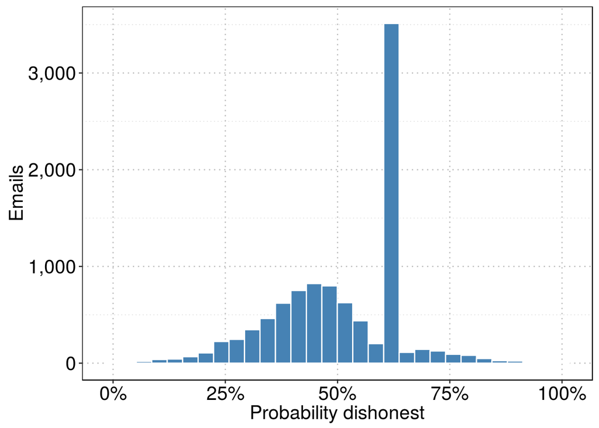

Figure 3: Probability that communication was dishonest

```r
# Plot overall probablity of dishonesty across all emails
stats %>%
    ggplot(aes(x = prob_lie)) +
    geom_histogram(fill = "steelblue", colour = "white") +
    xlab("Probability dishonest") +
    ylab("Emails") +
    scale_x_continuous(labels = scales::percent) +
    scale_y_continuous(labels = scales::comma) +
    theme_jim
```

These probabilities can also be viewed for each of the four clusters detected by the walktrap method, as shown in figure four.

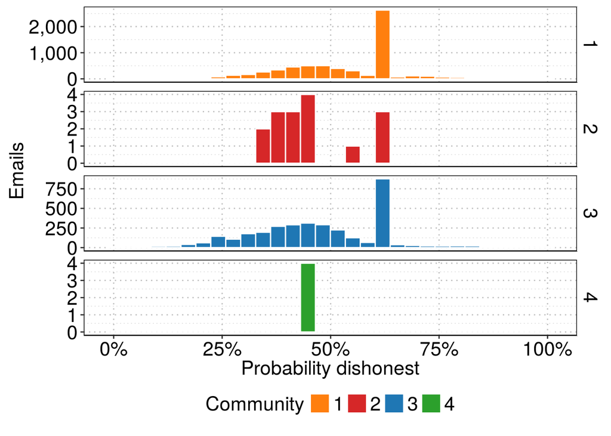

Figure 4: Probability that communication was dishonest by walktrap-detected community

```r
# Plot overall probablity of dishonesty across all emails, now per walktrap group
stats %>%
    mutate(Community = as.factor(cl_walk)) %>%
    ggplot(aes(x = prob_lie, fill = Community)) +
    geom_histogram(colour = "white") +
    xlab("Probability dishonest") +
    ylab("Emails") +
    scale_fill_manual(values = c("#ff7f0e", "#d62728", "#1f77b4", "#2ca02c")) +
    scale_y_continuous(labels = scales::comma) +
    facet_grid(cl_walk ~ ., scales = "free_y") +
    scale_x_continuous(labels = scales::percent) +
    theme_jim
```

## 6.4 Importance and dishonesty

Table 3 shows individuals with their importance ranks and associated predicted probabilities of being dishonest.

```r
# Summarise data at individual level
stats_summary <- stats %>%
    group_by(from) %>%
    summarise(prob_lie = mean(prob_lie, na.rm = T),
              eig_norm = mean(eig_norm),
              bet_norm = mean(bet_norm),
              clo_norm = mean(close_norm),
              sent = mean(sent)) %>%
    mutate(eig_rank = row_number(desc(eig_norm)),
           bet_rank = row_number(desc(bet_norm)),
           clo_rank = row_number(desc(clo_norm))) %>%
    select(from, sent, eig_rank, bet_rank, clo_rank, prob_lie) %>%
    arrange(eig_rank)

# Display in DT
DT::datatable(stats_summary %>% mutate(prob_lie = round(100*prob_lie, 1)),
              colnames = c("Sender", "Emails Sent", "Eigenvector importance rank",
                           "Betweenness importance rank",
                           "Closeness importance rank", "Average probability dishonest (%)"),
              caption = "Table 3: Importance ranks and dishonesty predictions")
```

|  | Sender | Emails Sent | Eigenvector importance rank | Betweenness importance rank | Closeness importance rank | Average probability dishonest (%) |
| --- | --- | --- | --- | --- | --- | --- |
| 1 | Hillary Clinton | 2814 | 1 | 1 | 1 | 45.5 |
| 2 | Huma Abedin | 2338 | 2 | 3 | 53 | 50.9 |
| 3 | Cheryl Mills | 2426 | 3 | 4 | 52 | 53.7 |
| 4 | Jake Sullivan | 1352 | 4 | 2 | 56 | 53.1 |
| 5 | Lauren Jiloty | 522 | 5 | 45 | 73 | 54.5 |
| 6 | Sidney Blumenthal | 380 | 6 | 65 | 58 | 53.2 |
| 7 | Lona Valmoro | 205 | 7 | 12 | 61 | 52.5 |
| 8 | Philippe Reines | 289 | 8 | 9 | 54 | 49.1 |
| 9 | Anne-Marie Slaughter | 295 | 9 | 10 | 62 | 47.7 |
| 10 | Richard Verma | 175 | 10 | 60 | 60 | 49.4 |

[output cut: 63 more lines]

The relationship between the importance of an email’s sender, and their average predicted probability of dishonesty is displayed in figures five, six and seven below (one figure per importance measure).

### 6.4.1 Eigenvector measures

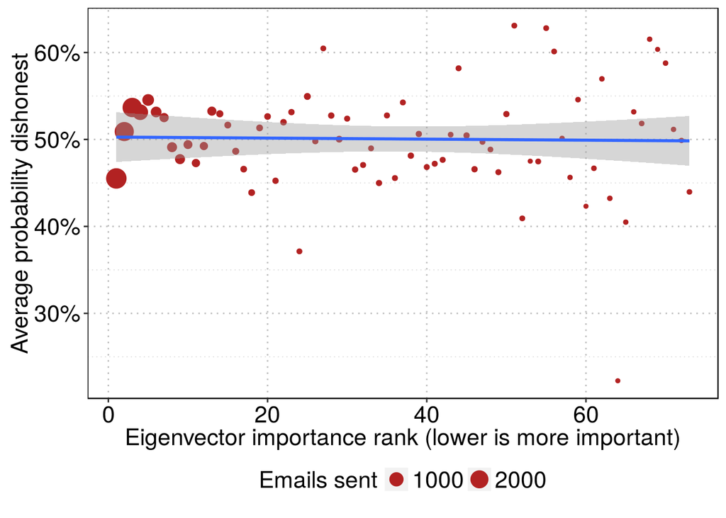

Figure 5: The relationship between eigenvector centrality measured importance and dishonesty, with linear fit to the data marked in blue.

```r
# Create plotting function
imp_lie_plot <- function(imp, xlab = "") {
stats_summary %>%
    ggplot(aes_string(x = imp, y = "prob_lie")) +
    geom_point(aes(size = sent), colour = "firebrick") +
    scale_y_continuous(labels = scales::percent) +
    xlab(xlab) +
    ylab("Average probability dishonest") +
    guides(size = guide_legend(title = "Emails sent")) +
    geom_smooth(method = "lm") +
    theme_jim
}

# Make the plot
imp_lie_plot("eig_rank", "Eigenvector importance rank (lower is more important)")
```

### 6.4.2 Betweenness measures

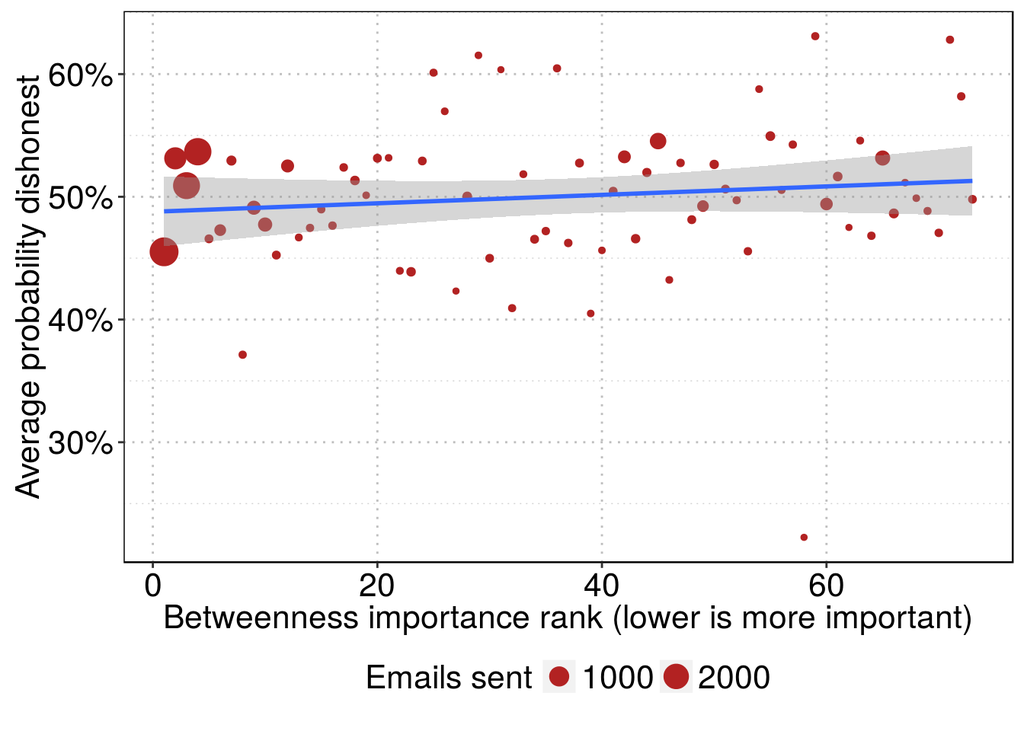

Figure 6: The relationship between betweenness centrality measured importance and dishonesty, with linear fit to the data marked in blue.

```r
# Make the plot
imp_lie_plot("bet_rank", "Betweenness importance rank (lower is more important)")
```

### 6.4.3 Closeness measures

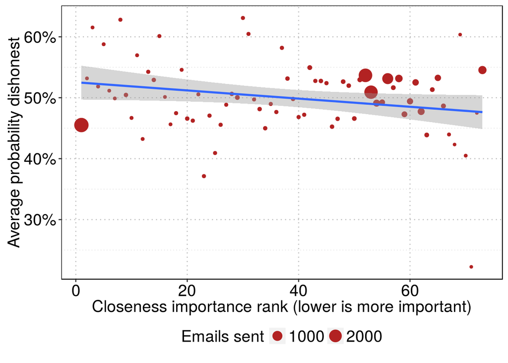

Figure 7: The relationship between closeness centrality measured importance and dishonesty, with linear fit to the data marked in blue.

```r
# Make the plot
imp_lie_plot("clo_rank", "Closeness importance rank (lower is more important)")
```

# 7 Conclusions

## 7.1 Detecting important individuals

The results of detection of important individuals in the network (table 2) can accurately detect individuals known to be important. Cheryl Mills was Counsellor and Chief of Staff to Mrs. Clinton Secretary of State; Huma Abedin was Mrs. Clinton’s Deputy Chief of Staff; Jake Sullivan is a foreign policy expert and advisor and was also a deputy Chief of Staff to Mrs. Clinton at the State Department. All three of these individuals were identified as the most important members of the network (after Mrs. Clinton herself) by both the eigenvector and betweenness centrality measures.

Closeness centrality does not perform well. It calculates, for each node, how close it is to all other nodes in the network based on the path length between it and the other nodes. In this instance, closeness centrality overestimates the importance of those nodes who are connected to Mrs. Clinton and no-one else. These nodes have a short path between themselves and other nodes: one that goes through Mrs. Clinton (who is connected to everyone). This, however, does not make them *important* in this context, and so this method does not perform well.

## 7.2 Detecting groups

The walktrap algorithm has detected sensible groups. The 4 communities it has detected can be summarised as follows: One appears to be those who have contacted Mrs. Clinton and at most one other person (typically no one); the second appears to be those who have contacted Mrs. Clinton but also many other members of the network. This second group contains the important individuals identified above and is therefore likely to be a group of interest. This demonstrates the effectiveness of the walktrap method in this setting where one cluster is highly connected and other groups in the network are not.

Of the remaining two groups, both are perhaps erroneous. The first, containing Bill and Chelsea Clinton is entirely disconnected from the remainder of the network. This is likely not true in reality, and simply a function of the low quality of the data extracted from the raw PDF documents. The final cluster, containing Jacob Lew and David Johnson should probably be included in the community that has primarily contacted Mrs. Clinton. It has perhaps been detected as it is the only pair of nodes where one node is connected directly to Mrs. Clinton, and the second node is connected to the first and no-one else.

The results from the betweenness method are much less concrete, that algorithm having detected 29 communities. There is no clear structure in any of the communities detected by this method and it has produced poor results.

## 7.3 Assessing dishonesty

The results of applying the dishonesty model reveal that, whilst most communications cannot be distinguished as either *strongly* honest or dishonest, most are predicted to be *mildly* dishonest. Considering the source of these emails, this is perhaps a worrying finding. There are, however, a large number that are predicted to be honest (<50% likelihood of being dishonest), and no virtually emails with a near-certain (> 80%) probability of being dishonest.

The two main groups detected show similar levels of potential dishonesty, with many predicted to be mildly (~60% probability) dishonest. The emails that are most strongly predicted to be dishonest come from these two clusters (although it is not possible to say if this is simply a function of the size of these clusters, or some inherent tendency towards dishonesty). Given the real-world importance of members of these groups (which contain both Mrs. Clinton and the individuals identified above), the overall tendency towards dishonesty is slightly concerning.

## 7.4 Dishonesty and importance

For each measures of importance investigated, there is no *significant* relationship between importance and the probability of dishonesty. Less important individuals show a high variation in predicted probability of dishonesty; important individuals appear to clustered closer to a 50/50 honest/dishonest prediction.

The absence of a relationship is interesting, however. The fact that an individual’s importance does not strongly affect their likelihood of (dis)honesty is potentially cause for concern: it would be hoped that important, influential figures with a say in (inter)national affairs would typically be more honest than others. It is pleasing to note that Mrs. Clinton herself has an overall probability of being *honest*, with an average probability of dishonesty of 45.5%.

## 7.5 Overall

The methods applied in this paper have had mixed results. Whilst analysis of Mrs. Clinton’s network through importance measures and community detection produced sensible and intuitive results; methods for identifying dishonesty in communications did not produce definitive results.

Perhaps as has been [noted](http://www.theguardian.com/commentisfree/2014/aug/27/why-politicians-must-lie-and-how-selling-ice-creams-is-like-an-election-campaign), politicians *are* dishonest, it is just that they are clever enough to use language to disguise this fact. Maybe, as discussed in a [Telegraph article](http://www.telegraph.co.uk/news/general-election-2015/politics-blog/11629927/Politicians-lie.-Get-over-it.html) that fact should just be accepted.

# 8 References

1. *Hillary Clinton Emails*, Kaggle, 2015, Available [online](https://www.kaggle.com/kaggle/hillary-clinton-emails);
2. *Network Analytics*, MSc. Business Analytics, 2015/16, *Professor Kalyan Talluri*;
3. *Introduction to social network methods*, 2005, Hanneman, Robert A. and Mark Riddle, Riverside, CA: University of California, Riverside. Available [oneline](http://faculty.ucr.edu/~hanneman/);
4. *Computing communities in large networks using random walks*, 2005, Pascal Pons, Matthieu Latapy. Available [online](http://arxiv.org/abs/physics/0512106);
5. *Finding and evaluating community structure in networks*, 2003, M. E. J. Newman, M. Girvan, Available [online](http://arxiv.org/abs/cond-mat/0308217);
6. *Lying Words: Predicting Deception From Linguistic Styles*, 2003, Newman et. al. Available [online](http://www.albany.edu/~zg929648/PDFs/Newman.pdf);
7. Linguistic Inquiry Word Count (LIWC). [Website](http://liwc.wpengine.com/);
8. *Tidy data*, 2013, Hadley Wickham. Available [online](https://www.jstatsoft.org/article/view/v059i10);
9. *Algorithms* 4<sup>th</sup> Ed., Sedgewick & Wayne. Available [online](http://algs4.cs.princeton.edu/home/);
10. *Why Politicians Must Lie…*, 2014, The Guardian. Available [online](http://www.theguardian.com/commentisfree/2014/aug/27/why-politicians-must-lie-and-how-selling-ice-creams-is-like-an-election-campaign);
11. *Politicians Lie, Get Over It*, 2015, The Telegraph. Available [online](http://www.telegraph.co.uk/news/general-election-2015/politics-blog/11629927/Politicians-lie.-Get-over-it.html);
12. *Community detection algorithms in igraph*, 2012, StackOverflow question response from igraph contributor. Available [online](http://stackoverflow.com/questions/9471906/what-are-the-differences-between-community-detection-algorithms-in-igraph)